# 326.212 Final Project: Part 2

## 2013-11086 김찬규

## Part 2. Basic Questions (150 pts)

### Q1. Monthly traffic in three airports (60 pts)

#### Q1-1

```r
airports_list = c("SNA", "SJC", "SMF")

tbl(con, "airports") %>%
  filter(IATA %in% airports_list)
```

```
## # Source:   lazy query [?? x 14]
## # Database: sqlite 3.29.0
## #   [/Users/jessekim/Projects/snu_stat/statistical_computing/project/project.sqlite]
##      id name  city  country IATA  ICAO  latitude longitude MAMSL   UTC
##   <dbl> <chr> <chr> <chr>   <chr> <chr>    <dbl>     <dbl> <dbl> <dbl>
## 1  3748 Norm… San … United… SJC   KSJC      37.4     -122.    62    -8
## 2  3817 Sacr… Sacr… United… SMF   KSMF      38.7     -122.    27    -8
## 3  3867 John… Sant… United… SNA   KSNA      33.7     -118.    56    -8
## # … with 4 more variables: continent <chr>, timezone <chr>, airport <chr>,
## #   OurAirports <chr>
```

- `SNA` belongs to John Wayne Airport-Orange County Airport.
- `SJC` belongs to Norman Y. Mineta San Jose International Airport.
- `SMF` belongs to Sacramento International Airport.

#### Q1-2

```r
flights <- tbl(con, "flights")

head(flights)
```

```
## # Source:   lazy query [?? x 30]
## # Database: sqlite 3.29.0
## #   [/Users/jessekim/Projects/snu_stat/statistical_computing/project/project.sqlite]
##    Year Month Day_of_Month Day_Of_Week Dep_Time CRS_Dep_Time Arr_Time
##   <dbl> <dbl>        <dbl>       <dbl> <chr>    <chr>        <chr>
## 1  2001     1            1           1 1000     0900         1242
## 2  2001     1            2           2 0906     0900         1125
## 3  2001     1            3           3 0901     0900         1157
## 4  2001     1            4           4 0954     0900         1217
## 5  2001     1            5           5 0855     0900         1131
## 6  2001     1            6           6 0910     0900         1201
## # … with 23 more variables: CRS_Arr_Time <chr>, Op_Unique_Carrier <chr>,
## #   OP_Carrier_FL_Num <dbl>, Tail_Num <chr>, Actual_Elapsed_Time <dbl>,
## #   CRS_Elapsed_Time <dbl>, Air_Time <dbl>, Arr_Delay <dbl>,
## #   Dep_Delay <dbl>, Origin <chr>, Dest <chr>, Distance <dbl>,
## #   Taxi_In <dbl>, Taxi_Out <dbl>, Cancelled <dbl>,
## #   Cancellation_Code <int>, Diverted <dbl>, Carrier_Delay <int>,
## #   Weather_Delay <int>, NAS_Delay <int>, Security_Delay <int>,
## #   Late_Aircraft_Delay <int>, X30 <int>
```

```r
airportcounts <- flights %>%
  filter(Dest %in% airports_list) %>%
  group_by(Year, Month, Dest) %>%
  summarize(counts = n()) %>%
  collect()

airportcounts
```

```
## # A tibble: 648 x 4
## # Groups:   Year, Month [216]
##     Year Month Dest  counts
##    <dbl> <dbl> <chr>  <int>
##  1  2001     1 SJC     6321
##  2  2001     1 SMF     3325
##  3  2001     1 SNA     3726
##  4  2001     2 SJC     5720
##  5  2001     2 SMF     2930
##  6  2001     2 SNA     3327
##  7  2001     3 SJC     6426
##  8  2001     3 SMF     3342
##  9  2001     3 SNA     3676
## 10  2001     4 SJC     6202
## # … with 638 more rows
```

#### Q1-3

```r
airportcounts <- airportcounts %>%
  ungroup() %>%
  mutate(
    Date = date(str_c(Year, Month, "1", sep = "-"))
  ) %>%
  select(
    Date, Dest, counts
  ) %>%
  arrange(
    Date
  )
airportcounts
```

```
## # A tibble: 648 x 3
##    Date       Dest  counts
##    <date>     <chr>  <int>
##  1 2001-01-01 SJC     6321
##  2 2001-01-01 SMF     3325
##  3 2001-01-01 SNA     3726
##  4 2001-02-01 SJC     5720
##  5 2001-02-01 SMF     2930
##  6 2001-02-01 SNA     3327
##  7 2001-03-01 SJC     6426
##  8 2001-03-01 SMF     3342
##  9 2001-03-01 SNA     3676
## 10 2001-04-01 SJC     6202
## # … with 638 more rows
```

#### Q1-4

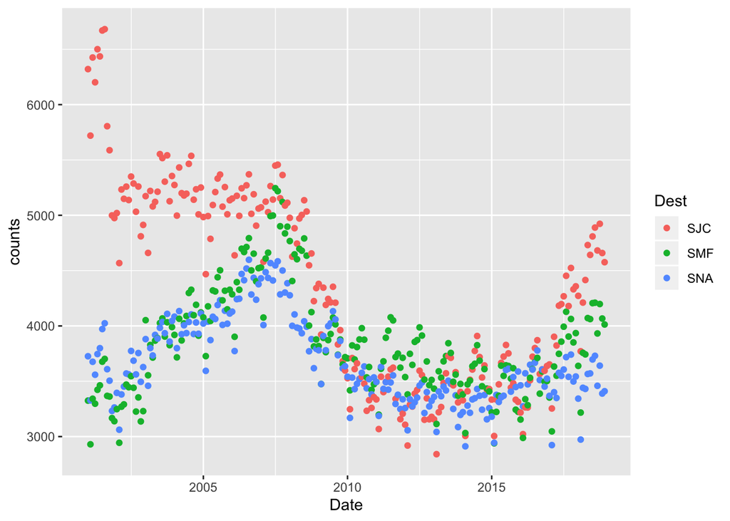

```r
airportcounts %>%
  ggplot(aes(Date, counts)) +
  geom_point(aes(color = Dest))
```

#### Q1-5

```r
for (airport in airports_list) {
  airportcounts %>%
  filter(Dest == airport) %>%
  arrange(desc(counts)) %>%
  head(., 10) %>%
  print()
}
```

```
## # A tibble: 10 x 3
##    Date       Dest  counts
##    <date>     <chr>  <int>
##  1 2006-08-01 SNA     4598
##  2 2007-08-01 SNA     4584
##  3 2007-05-01 SNA     4568
##  4 2007-07-01 SNA     4547
##  5 2006-07-01 SNA     4519
##  6 2007-10-01 SNA     4501
##  7 2007-03-01 SNA     4486
##  8 2006-05-01 SNA     4470
##  9 2006-10-01 SNA     4435
## 10 2007-04-01 SNA     4434
## # A tibble: 10 x 3
##    Date       Dest  counts
```

[output cut: 24 more lines]

### Q2. Finding reliable airlines (60 pts)

#### Q2-1

```r
airlines_list = c("UA", "DL", "AA", "MQ")

delays <- dplyr::tbl(con, "flights") %>%
  filter(
    Origin == "ORD",
    Dest == "MSP",
    Year == 2015,
    Op_Unique_Carrier %in% airlines_list
  ) %>%
  select(
    Year, Month, Day_of_Month, Op_Unique_Carrier, Arr_Delay
  ) %>%
  group_by(
    Year, Month, Day_of_Month, Op_Unique_Carrier
  ) %>%
  summarize(
    mean_delay = mean(Arr_Delay, na.rm = TRUE)
  ) %>%
  collect() %>%
  ungroup() %>%
  mutate(
    Date = date(str_c(Year, Month, Day_of_Month, sep = "-"))
  ) %>%
  select(
    Date, Op_Unique_Carrier, mean_delay
  )

delays
```

```
## # A tibble: 1,193 x 3
##    Date       Op_Unique_Carrier mean_delay
##    <date>     <chr>                  <dbl>
##  1 2015-01-01 AA                    120.
##  2 2015-01-01 DL                    -12.5
##  3 2015-01-01 MQ                      2.33
##  4 2015-01-02 AA                    -10.5
##  5 2015-01-02 DL                     -1
##  6 2015-01-02 MQ                      3.33
##  7 2015-01-03 AA                    124.
##  8 2015-01-03 DL                     48.5
##  9 2015-01-03 MQ                     20
## 10 2015-01-04 AA                    101.
## # … with 1,183 more rows
```

#### Q2-2

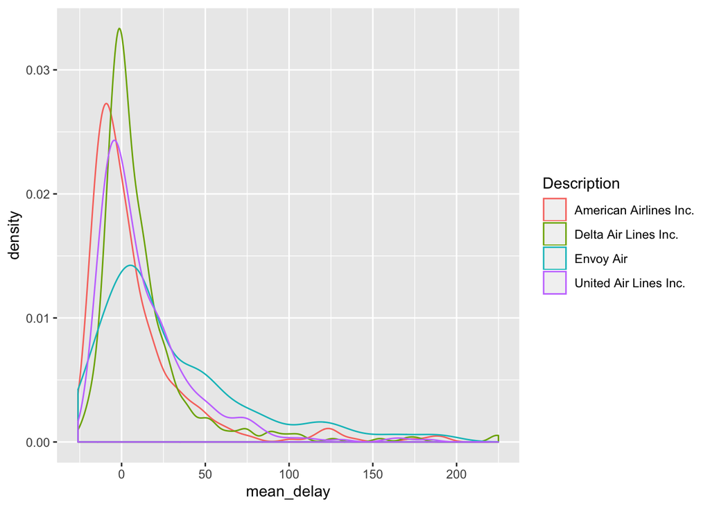

```r
airlines <- tbl(con, "airlines") %>% collect()

delays %>%
  left_join(
    airlines,
    by = c("Op_Unique_Carrier" = "Code")
  ) %>%
  ggplot(aes(mean_delay)) +
  geom_density(aes(color = Description), na.rm = TRUE)
```

It seems Delta airlines best observes the scheduled arrival time with mean arrival delay nearest to zero and minimal variance of delay times among four airlines.

However, Envoy airlines seems to be least reliable with largest mean arrival delay and biggest variance of delay times among four airlines.

### Q3. All flights (30 pts)

#### Q3-1

```r
# Flights data in 2001
flights_2001 <- tbl(con, "flights") %>%
  select(
    Year, Month, Day_of_Month, Day_Of_Week, Cancelled
  ) %>%
  filter(
    Year == 2001,
    Day_Of_Week == 1
  ) %>%
  group_by(Year, Month, Day_Of_Month) %>%
  summarize(
    counts = n(),
    cancelled = sum(Cancelled, na.rm = TRUE)
  ) %>%
  collect() %>%
  ungroup() %>%
  mutate(
    Date = date(str_c(Year, Month, Day_of_Month, sep = "-"))
  ) %>%
  select(Date, counts, cancelled)

flights_2001
```

```
## # A tibble: 53 x 3
##    Date       counts cancelled
##    <date>      <int>     <dbl>
##  1 2001-01-01  16081      1190
##  2 2001-01-08  17491       506
##  3 2001-01-15  17510       664
##  4 2001-01-22  17534       428
##  5 2001-01-29  17533      1165
##  6 2001-02-05  17473      1599
##  7 2001-02-12  17472       548
##  8 2001-02-19  17343       294
##  9 2001-02-26  17543       502
## 10 2001-03-05  17570      2821
## # … with 43 more rows
```

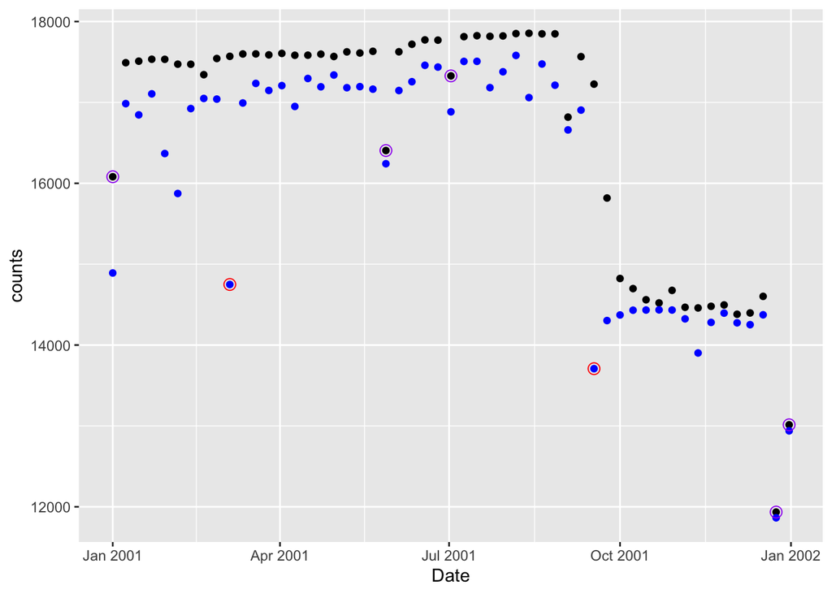

```r
# Plot for 2001 data
flights_2001_holidays <- flights_2001 %>%
  filter(
    Date %in% ymd(c(
      "2001-01-01", # New Year's Day
      "2001-05-28", # Memorial Day
      "2001-07-02", # Independence Day
      "2001-12-24", # Christmas Day
      "2001-12-31" # New Year's Day
    ))
  )

flights_2001_cancels <- flights_2001 %>%
  filter(
    cancelled > 2000
  )

flights_2001 %>%
  ggplot(aes(Date)) +
  geom_point(aes(y = counts)) +
  geom_point(aes(y = counts - cancelled), color = "blue") +
  geom_point(
    data = flights_2001_holidays,
    aes(y = counts),
    size = 3,
    shape = 1,
    color = "purple"
  ) +
  geom_point(
    data = flights_2001_cancels,
    aes(y = counts - cancelled),
    size = 3,
    shape = 1,
    color = "red"
  )
```

Black points in the above graph describe the number of all flights for each day. Blue points describe the number of all flights which were not cancelled. Purple circles describe the days that protrude from overall trend. Red circles describe the days with abnormally high cancellation rate.

There is a slight increase of the number of flights through the summertime, that is, from July to September. This may be the effect of summer vacation.

However, there is a drastical drop in number of flights in the middle of September, from 16,906 in 2001-09-10 to 13,708 in 2001-09-17. Then the number of flights remains low throughout the year. Noting that the `9.11 Terror` occured at 2001-09-11, it is reasonable that the number of flights dropped because people began to fear flights. Actually, many airlines including SABENA Belgian Airlines, Swiss Airlines went bankrupt after the terror. (Referenced to [911 테러-나무위키](https://namu.wiki/w/9.11%20%ED%85%8C%EB%9F%AC))

There also are notable outliers in the number of flights. That is, There are notable drop of flights in 1/1, 5/28, 7/2, 12/24, 12/31 (Check out pirple-circled points). It seems they are related with american federal holidays. 1/1 is New Year’s Day, 5/28 is Memorial Day, 7/4 is Independence Day, 12/25 is Christmas Day and 12/31 is day before New Year’s Day again. People tend to stay home in these days.

More than 2,000 cancellations are observed at 2001-03-05 (Check out red-circled points). There was a big storm from 2001-03-04 to 2001-03-06. (http://www.raymondcmartinjr.com/weather/2001/05-Mar-01.html)

#### Q3-2

```r
# Flights data in 2011
flights_2011 <- tbl(con, "flights") %>%
  select(
    Year, Month, Day_of_Month, Day_Of_Week, Cancelled
  ) %>%
  filter(
    Year == 2011,
    Day_Of_Week == 1
  ) %>%
  group_by(Year, Month, Day_Of_Month) %>%
  summarize(
    counts = n(),
    cancelled = sum(Cancelled, na.rm = TRUE)
  ) %>%
  collect() %>%
  ungroup() %>%
  mutate(
    Date = date(str_c(Year, Month, Day_of_Month, sep = "-"))
  ) %>%
  select(Date, counts, cancelled)

flights_2011
```

```
## # A tibble: 52 x 3
##    Date       counts cancelled
##    <date>      <int>     <dbl>
##  1 2011-01-03  17381       146
##  2 2011-01-10  16743      2761
##  3 2011-01-17  16652       563
##  4 2011-01-24  16695       186
##  5 2011-01-31  16698       587
##  6 2011-02-07  16881       363
##  7 2011-02-14  16817       189
##  8 2011-02-21  17157       741
##  9 2011-02-28  17261       475
## 10 2011-03-07  17420       264
## # … with 42 more rows
```

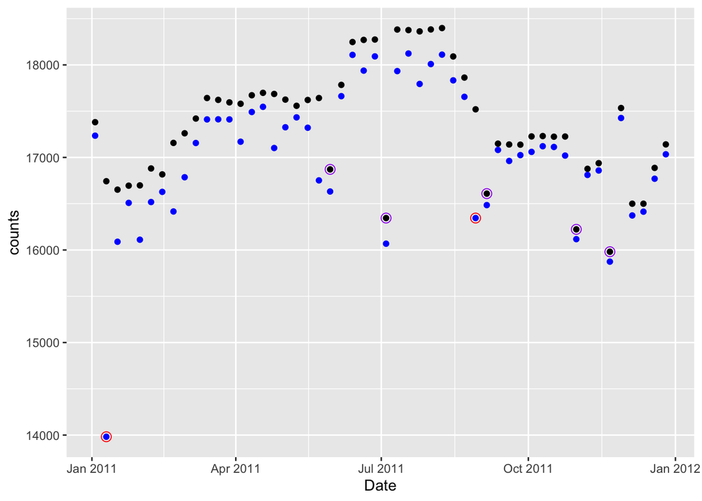

```r
# Plot for 2011 data
flights_2011_holidays <- flights_2011 %>%
  filter(
    Date %in% ymd(c(
      "2011-05-30", # Memorial Day
      "2011-07-04", # Independence Day
      "2011-09-05", # Labor Day
      "2011-10-31", #
      "2011-11-21" # Thanksgiving Day
    ))
  )

flights_2011_cancels <- flights_2011 %>%
  filter(
    cancelled > 1000
  )

flights_2011 %>%
  ggplot(aes(Date)) +
  geom_point(aes(y = counts)) +
  geom_point(aes(y = counts - cancelled), color = "blue") +
  geom_point(
    data = flights_2011_holidays,
    aes(y = counts),
    size = 3,
    shape = 1,
    color = "purple"
  ) +
  geom_point(
    data = flights_2011_cancels,
    aes(y = counts - cancelled),
    size = 3,
    shape = 1,
    color = "red"
  )
```

The number of flights is highest with about 18,000 each day during the summertime. Compared to the data of year 2001, it seems that a larger amount of people go to vacation thorough flights during the summer vacation. The increased vacation flights would be due to general increase of income level and globalization.

There are also notable outliers in the data. That is, the number of flights drops at 5/30, 7/4, 9/5, 10/31, 11/21 (Check out purple-circled points). Note that 5/30 is Memorial Day, 7/4 is Independence Day, 9/5 is Labor Day, 11/24 is Thanksgiving Day. The number of flights usually drops around the federal holidays. Compared to the data from year 2001, the number of flights increased at New Year’s Day and Christmas Day.

There are about 3,000 flights cancellation at 1/10 and about 1,200 flights cancellation at 8/29 (Check out red-circled points). We can see from the cancellations code that most of the cancellation is due to weather.

```r
# Cancellation code of 2011-01-10
tbl(con, "flights") %>%
  filter(
    Year == 2011,
    Month == 1,
    Day_of_Month == 10,
    !is.na(Cancellation_Code)
  ) %>%
  group_by(Cancellation_Code) %>%
  summarize(n = n())
```

```
## # Source:   lazy query [?? x 2]
## # Database: sqlite 3.29.0
## #   [/Users/jessekim/Projects/snu_stat/statistical_computing/project/project.sqlite]
##   Cancellation_Code     n
##   <chr>             <int>
## 1 A                   794
## 2 B                  1955
## 3 C                    12
```

```r
# Cancellation code of 2011-08-29
tbl(con, "flights") %>%
  filter(
    Year == 2011,
    Month == 8,
    Day_of_Month == 29,
    !is.na(Cancellation_Code)
  ) %>%
  group_by(Cancellation_Code) %>%
  summarize(n = n())
```

```
## # Source:   lazy query [?? x 2]
## # Database: sqlite 3.29.0
## #   [/Users/jessekim/Projects/snu_stat/statistical_computing/project/project.sqlite]
##   Cancellation_Code     n
##   <chr>             <int>
## 1 A                   110
## 2 B                  1059
## 3 C                     6
```

Actually, there was a very big winter storm at 2011-01-10, according to US national weather service. (Referred to https://www.weather.gov/ffc/20110109winterstorm) Also there was a hurricane named “Irene” around 2011-08-29. (Referred to https://en.wikipedia.org/wiki/Hurricane_Irene)

```r
dbDisconnect(con)
```